# Второй этап индивидуального проекта

Установка DVWA

Барето Вилиан Мануел

Российский университет дружбы народов, Москва, Россия

21 марта 2026

# Информация

## Докладчик

- Барето Вилиан Мануел
- НКАбд 03-24
- Факультет Физико-математических и естесвенных наук
- Российский университет дружбы народов
- 1032239248@rudn.ru

# Цель работы

Получить практические навыки по установке DVWA.

# Задание

1. Установить DVWA.

# Выполнение лабораторной работы

## репзиторий DVWA

Открою github и захожу в репозиторий dvwa и копирую ссылку.

[figure not shown]

репзиторий DVWA

## Клонирование DVWA в /html

Открою терминал, и с помощью cd, вхожу в директорию html, где сохраняются файлы локального хоста. В этой же директории клонирую репозиторий.

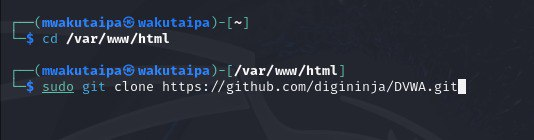

Клонирование DVWA в /html

## chmod -R 777

С помощью ls поверяю, что клонирование было успешно и потом разрешаю все права на все файлы в DVWA используя chmod -R 777

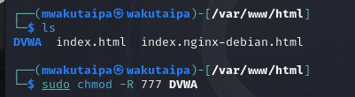

chmod -R 777

## директория config

Проверяю работу и захожу в dvwa/config, чтобы настроить веб-приложение.

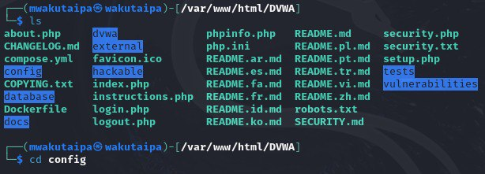

директория config

## копирование config.int.php

Далее копирую config.int.php который содержит конфигурацию приложения.

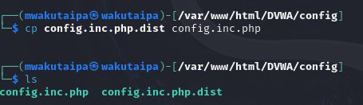

копирование config.int.php

## редактирование файла конфигурации

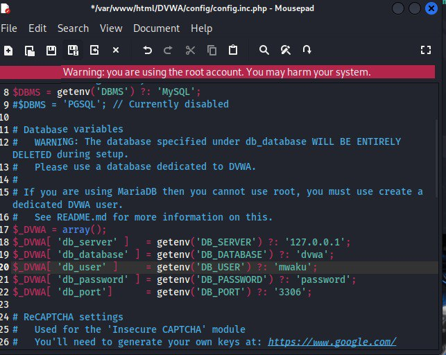

редактирование файла конфигурации

## Запуск mysql

Запускаю mysql с помощью start mysql и проверяю используя status mysql.

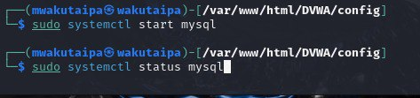

Запуск mysql

## проверка работы mysql

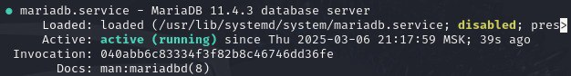

проверка работы mysql

## вход в mysql

Далее я вхожу в mmysql используя mysql -u root -p

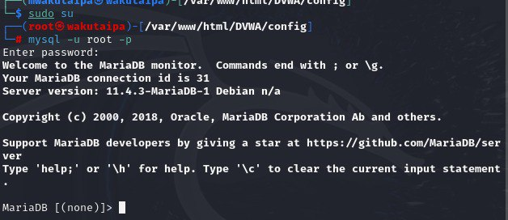

вход в mysql

## создание пользоателя

Создаю базу данных waku и нового пользователя используя create user ‘mwaku’@‘127.0.0.1’ identified by ‘password’. Используя эту команду, создала пользователя mwaku, работаюшего на сервер локального хоста (127.0.0.1) и пароль password.

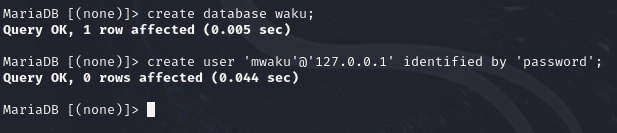

создание пользоателя

## Разрешение права

Разрешаю все правав доступа этому пользователю к базе данных и завершаю работы.

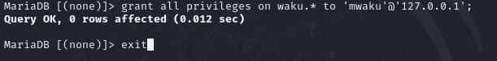

Разрешение права

## Запуск apache2

Запускаю сервер apache2.

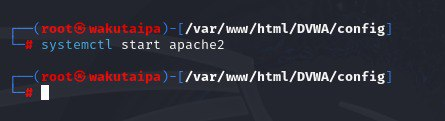

Запуск apache2

## вход в /etc/php/8.2

Далее вхожу в /etc/php/8.2.

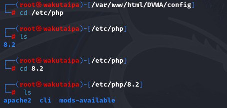

вход в /etc/php/8.2

## Включение allow_url

Включаю значения allow_url_fopen и allow_url_include в файле apache2/php.ini.

[figure not shown]

Включение allow_url

## Перезапуск apache2

Перезапускаю сервер apache2 испоьзуя systemctl restart apache2.

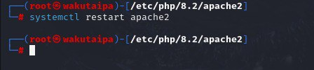

Перезапуск apache2

## страница веб-приложения

Открою 127.0.0.1./dvwa/setup.php в браузере.

[figure not shown]

страница веб-приложения

## Вход в DVWA

Нажимаю кнопку create/Reset database. Создается базу данных и мне перенаправляют на страницу входа. Вхожу используя логин admin и пароль p@ssword.

[figure not shown]

Вход в DVWA

## Домшняя страница dvwa

После входа попадаем на домашнюю страницу dvwa.

[figure not shown]

Домшняя страница dvwa

# Выводы

Получила навыки по установке DVWA.

# Список литературы

[Set up DVWA in Kali Linux][https://akshaygupta21.medium.com/how-to-setup-dvwa-in-kali-linux-e7c0dc272bba]